# Position Adjustments

- `position = "identity"` will place each other object exactly where it falls in the context of the graph. This is not very useful bars, because it overlaps them. To see that overlapping we either need to make the bars slightly transparent by setting `alph` to a small value, or completely transparent by setting `fill = NA`

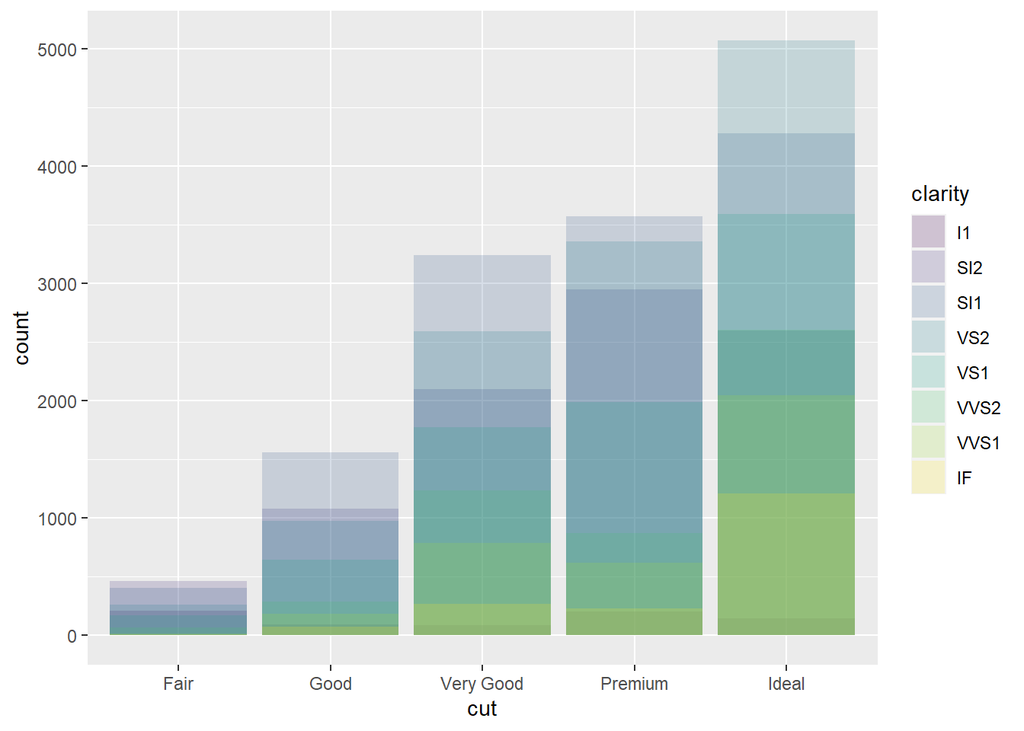

```r
ggplot(
  data = diamonds,
  mapping = aes(x = cut, fill = clarity)
) +
  geom_bar(alpha = 1/5, position = "identity")
```

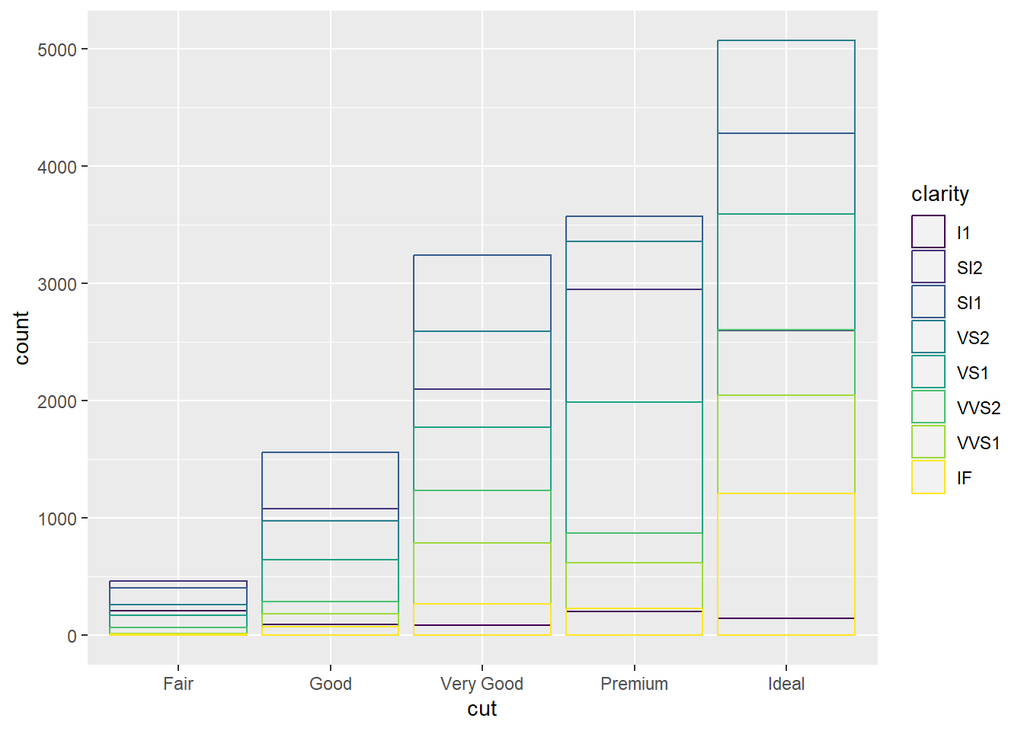

```r
ggplot(
  data = diamonds,
  mapping = aes(x = cut, color = clarity)
) +
  geom_bar(fill = NA, position = "identity")
```

The identity position adjustment is more useful for 2D geoms, like points, where it is default.